# Gas weather report: July 21st - July 27th

Do gas limit increases decrease gas prices?

Barnabé Monnot https://twitter.com/barnabemonnot (Robust Incentives Group, Ethereum Foundation)https://github.com/ethereum/rig  
2020-08-06

### Table of Contents

The data includes all blocks produced between July 21st, 2020, 02:00:17 UTC (block 10500001) and July 27th, 2020, 06:37:09 UTC (block 10540000). It was obtained from [Geth](https://geth.ethereum.org/) using a [DAppNode](https://dappnode.io) full node with the wonderful ethereum-etl package from Evgeny Medvedev to extract transaction and block details.

You can check the source for this notebook [here (R notebook)](https://github.com/ethereum/rig/tree/master/ethdata/notebooks/gas_weather_reports/exploreJuly21.Rmd). See a previous report [here](https://ethereum.github.io/rig/ethdata/notebooks/explore_data.html).

## Block properties

### Gas used by a block

Miners have some control over the gas limit of a block, but how much gas do blocks generally use?

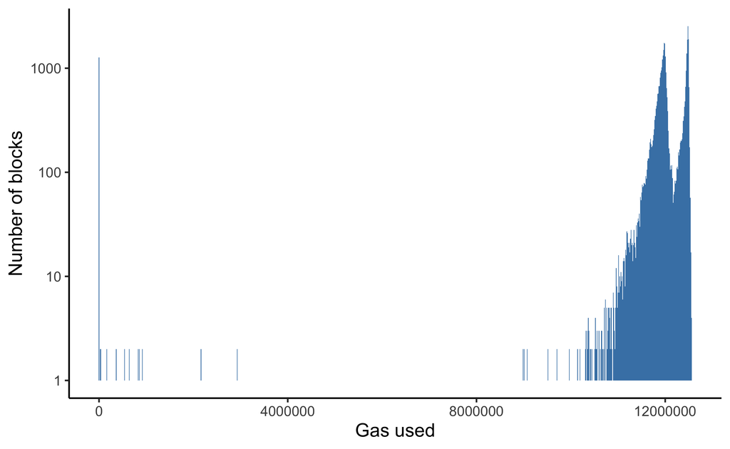

The gas limit was increased from the previous limit of 10M gas, and gas used in blocks soon followed. We notice two peaks. Let’s zoom in.

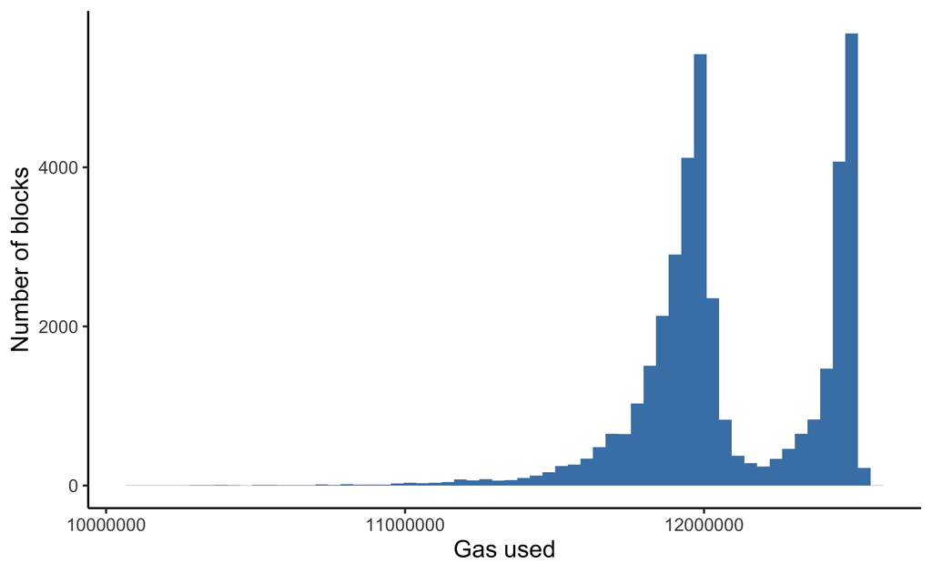

How did the gas limit evolve over time?

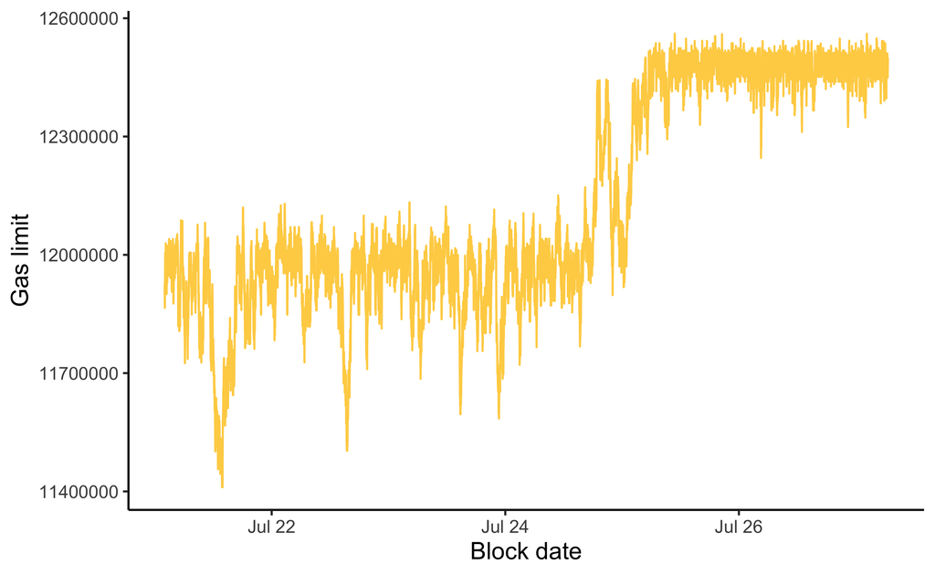

We have a shift in the middle of the week from about 12M gas limit to 12.5M. Did this release some pressure from transaction fees?

## Gas prices

### Distribution of gas prices

First, some descriptive stats for the distribution of gas prices.

| Quartile | Value |
| --- | --- |
| 0.00 | 0.00000000 |
| 0.25 | 58.00000000 |
| 0.50 | 74.28724683 |
| 0.75 | 90.00000000 |
| 1.00 | 493956.20354572 |

75% of included transactions post a gas price less than or equal to 90 Gwei. This is much higher than in our last [gas weather report in May](https://ethereum.github.io/rig/ethdata/notebooks/explore_data.html).

### Evolution of gas prices

To compute the average gas price in a block, I do a weighted mean using `gas_used` as weight. I then compute the average gas price over 100 blocks by doing another weighted mean using the total gas used in the blocks.

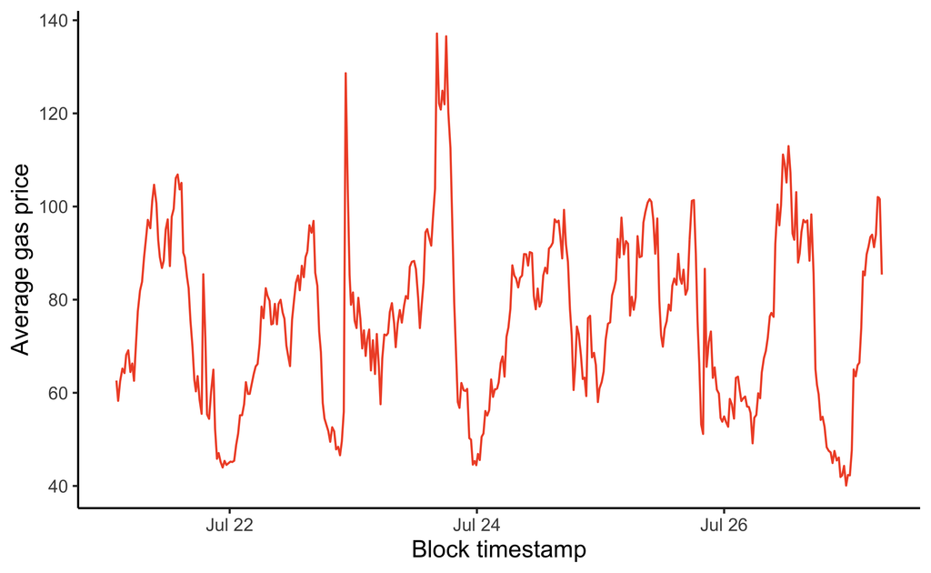

We see a daily seasonality, with peaks and troughs corresponding to high congestion and low congestion hours of the day.

Did increasing the gas limit reduce the prices overall? We can take a look visually.

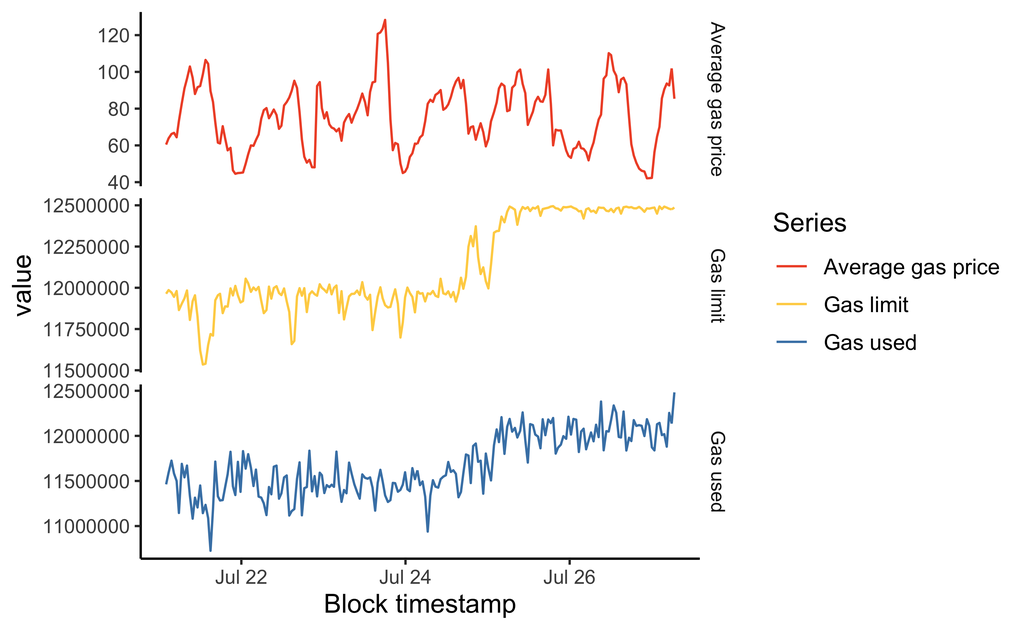

It doesn’t seem like it did to me, even though the average gas used in blocks increased in concert with the gas limit. We can look at average prices for transactions in blocks with gas limit lesser than 12.25M gas (“small blocks”) vs. blocks with gas limit greater than 12.25M (“big blocks”).

| big_block | avg_gas_price |
| --- | --- |
| Big block | 75.42838546 |
| Small block | 75.36684040 |

The two averages are mighty close to each other, with big blocks posting even slightly higher gas prices than small ones (a negligible difference however).

**Addendum:** Vitalik performed a thorough analysis two years ago looking at [demand elasticity to the block size (on ethresear.ch)](https://ethresear.ch/t/estimating-cryptocurrency-transaction-demand-elasticity-from-natural-experiments/2330). You can also check [his tweet](https://twitter.com/VitalikButerin/status/1288082095051546624) mentioning elasticity close to 1. With gas limit upped from 12M to 12.5M (a mere 4% increase), the result we observe here is not suprising.